# tf21147_EMATM0061_B_Report

Kahim Wong

11/12/2021

## B.1

In this question we consider a security system at a factory. A sensor is designed to make a sound if a person walks within one metre of the gate. However, the sensor is not perfectly reliable: It sometimes makes a sound when there is no one present, and sometimes fails to make a sound when someone is present.

For simplicity we will view the passage of time as being broken down into a series of phases lasting exactly one minute. For each minute, we let p0 denote the conditional probability that the sensor makes a sound if there is no person within one metre of the gate, during that minute. Moreover, for each minute, we let p1 denote the conditional probability that the sensor makes a sound at least once, if there is at least one person present, during that minute. Suppose also that the probability that at least one person walks within one metre of the gate over any given minute is q. Again, for simplicity, we assume that p0,p1,q ∈ [0, 1] are all constant. Let ϕ denote the conditional probability that at least one person has passed within one metre of the gate during the current minute, given that the alarm has made a sound during that minute.

1. Write a function called c_prob_person_given_alarm which gives ϕ as a function of p0,p1 and q.

A denotes event least one person walks within one metre of the gate over any given minute  
B denotes event the sensor makes a sound

Given $P(A)=q$, $P(B \mid A^{c})= p_{0}$, $P(B \mid A)= p_{1}$

compute $\phi$

$\phi=P(A \mid B)=\frac{P(A)P(B \mid A)}{P(B)}$

Since,
$$\begin{align*}
P(B)&=P(B \mid A)P(A)+P(B \mid A^{c})P(A^{c}) \\
&=p_{1}q+p_{0}(1-q)
\end{align*}$$

Therefore,
$$\begin{align*}
\phi&=\frac{P(A)P(B \mid A)}{P(B)} \\
&=\frac{qp_{1}}{p_{1}q+p_{0}(1-q)}
\end{align*}$$

```r
library(tidyverse)
c_prob_person_given_alarm<-function(p0, p1, q){
  return(p1*q/(p1*q+p0*(1-q)))
}
```

2. Consider a setting in which p0 = 0.05, p1 = 0.95 and q = 0.1. In this case, what is ϕ?

```r
c_prob_person_given_alarm(p0=0.05, p1=0.95, q=0.1)
```

```
## [1] 0.6785714
```

3. Next consider a setting in which p0 = 0.05, p1 = 0.95 and generate a plot which shows ϕ as we vary q. That is, you should display a curve which has q along the horizontal axis and the corresponding value of ϕ along the vertical axis.

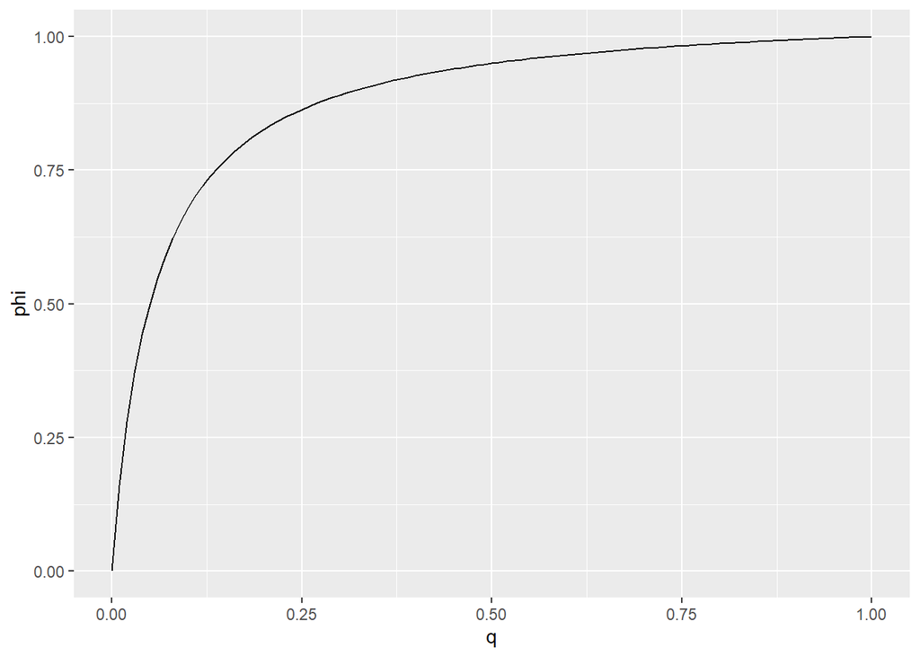

```r
q<-seq(0,1,0.01)
phis<-c_prob_person_given_alarm(p0=0.05, p1=0.95, q=q)
result_df<-data.frame(q=q, phi=phis)
ggplot(result_df, aes(x=q, y=phi))+geom_line()+labs(x="q", y="phi")
```

## B.2

1. What is the probability mass function pX : R → [0, 1] for X?

$$p_{X}=\begin{cases}
\begin{align*}
1-\alpha-\beta-\gamma \quad if \quad X=0 \\
\alpha \quad if \quad X=1 \\
\beta \quad if \quad X=2 \\
\gamma \quad if \quad X=5 \\
0 \quad otherwise.
\end{align*}
\end{cases}$$

2. Give an expression for the expectation of X in terms of α,β,γ.

$\mathbb{E}[X]=\alpha+2\beta+5\gamma$

3. Give an expression for the population variance of X in terms of α,β,γ.

$Var(X)=\mathbb{E}[X^2]-\mathbb{E}[X]^2=\alpha+4\beta+25\gamma-(\alpha+2\beta+5\gamma)^2$

4. Give an expression for the expectation of the random variable X in terms of α,β,γ.

$$\begin{align*}
\mathbb{E}(\overline X)&=\mathbb{E}(\frac{1}{n} \sum_{i=1}^{n} X_{i} ) \\
&=\frac{1}{n} \mathbb{E}( \sum_{i=1}^{n} X_{i} ) \\
&=\frac{1}{n} \sum_{i=1}^{n} \mathbb{E}( X_{i} ) \\
&=\frac{1}{n} \cdot n \cdot (\alpha+2\beta+5\gamma) \\
&=\alpha+2\beta+5\gamma
\end{align*}$$
(e) Give an expression for the population variance of the random variable X in terms of α,β,γ.

$$\begin{align*}
Var(\overline X)&=Var(\frac{1}{n} \sum_{i=1}^{n} X_{i} ) \\
&=(\frac{1}{n})^2 Var( \sum_{i=1}^{n} X_{i} ) \\
&=(\frac{1}{n})^2 \sum_{i=1}^{n} Var(X_{i}) \\
&=(\frac{1}{n})^2 \cdot n \cdot (\alpha+4\beta+25\gamma-(\alpha+2\beta+5\gamma)^2) \\
&=\frac{1}{n} \cdot (\alpha+4\beta+25\gamma-(\alpha+2\beta+5\gamma)^2)
\end{align*}$$

6. Create a function called sample_X_0125() which takes as inputs α, β, γ and n and outputs a sample X1, . . . , Xn of independent copies of X where P (X = 1) = α, P (X = 2) = β, P (X = 5) = γ and P (X /∈ {0, 1, 2, 5}) = 0.

```r
sample_X_0125<-function(alpha, beta, gamma, n){
  sample_X<-data.frame(U=runif(n))%>%
    mutate(X=case_when(
      (0<=U)&(U<alpha)~1,
      (alpha<=U)&(U<alpha+beta)~2,
      (alpha+beta<=U)&(U<alpha+beta+gamma)~5,
      (alpha+beta+gamma<=U)&(U<=1)~0))%>%
    pull(X)
  return(sample_X)
}
```

```r
alpha<-0.1
beta<-0.2
gamma<-0.3
n<-10000
set.seed(0)
sample_X<-sample_X_0125(alpha, beta, gamma, n)
X_mean<-mean(sample_X)
X_mean
```

```
## [1] 2.0069
```

```r
X_Var<-var(sample_X)
X_Var
```

```
## [1] 4.405093
```

```r
X_mean_expect<-alpha+2*beta+5*gamma
X_mean_expect
```

```
## [1] 2
```

```r
X_Var_expect<-alpha+4*beta+25*gamma-((alpha+2*beta+5*gamma)^2)
X_Var_expect
```

```
## [1] 4.4
```

8. Once again, take α = 0.1, β = 0.2, γ = 0.3. Conduct a simulation study to explore the behavior of the sample mean. Your study should involve 10000 trials. In each trial, you should set n = 100 and create a sample X1, . . . , Xn of independent and identically distributed random variables with P (Xi = 1) = α, P (Xi = 2) = β, P (Xi = 5) = γ and P (Xi ∈ { / 0, 1, 2, 5}) = 0 for i = 1, . . . , n. For each of the 10000 trials, compute the corresponding sample mean X based on X1, . . . , Xn.

```r
num_trials<-10000
sample_size<-100
set.seed(0)
sample_X_trails_10000<-data.frame(trial=seq(num_trials))%>%
  mutate(sample=map(.x=trial,.f=~sample_X_0125(alpha, beta, gamma, sample_size)))%>%
  mutate(mean=map_dbl(.x=sample, .f=~mean(.x)))
```

1. Generate a histogram plot which displays the behavior of the sample mean within your simulation study. Use a bin width of 0.02.

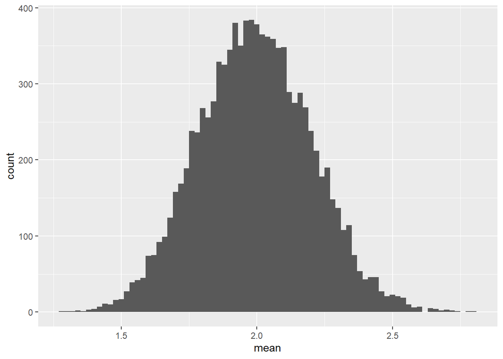

```r
sample_X_trails_10000%>%
  ggplot(aes(x=mean))+geom_histogram(binwidth = 0.02)
```

(j) What is the numerical value of the expectation E(X) in your simulation study? What is the numerical value of the variance Var(X)? Give your answers to 4 decimal places.

```r
numerical_E<-alpha+2*beta+5*gamma
numerical_E
```

```
## [1] 2
```

```r
numerical_Var<-(1/sample_size)*(alpha+4*beta+25*gamma-((alpha+2*beta+5*gamma)^2))
numerical_Var
```

```
## [1] 0.044
```

```r
mean_sets<-sample_X_trails_10000%>%
  pull(mean)
estimate_E<-mean(mean_sets)
estimate_E
```

```
## [1] 1.998741
```

```r
estimate_Var<-var(mean_sets)
estimate_Var
```

```
## [1] 0.04322803
```

Let fµ,σ2 : R → [0, ∞) be the probability density function of a Gaussian random variable with distribution N (µ, σ2), so that the population mean is µ and the population variance is σ2.